# SMPE

PHILIBERT Manon, POLET Pierre-Etienne, SINTIARI Ni Luh Dewi

December 1, 2016

```r
knitr::opts_chunk$set(echo = TRUE)
library(ggplot2)
```

# 1 : First look at the dataset

We take the data provided by the teacher and plot it to have an overview.

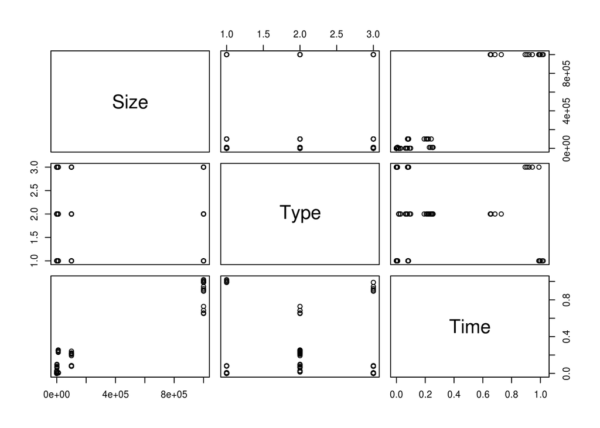

```r
data = read.csv("archive_quicksort/_measurements.csv")
plot(data)
```

```r
head(data)
```

```
##   Size        Type     Time
## 1  100  Sequential 0.000040
## 2  100    Parallel 0.028658
## 3  100    Built-in 0.000045
## 4  100  Sequential 0.000050
## 5  100    Parallel 0.027857
## 6  100    Built-in 0.000043
```

Next we organise it to see the time of execution of each algorithm related to the size of the sorted list.

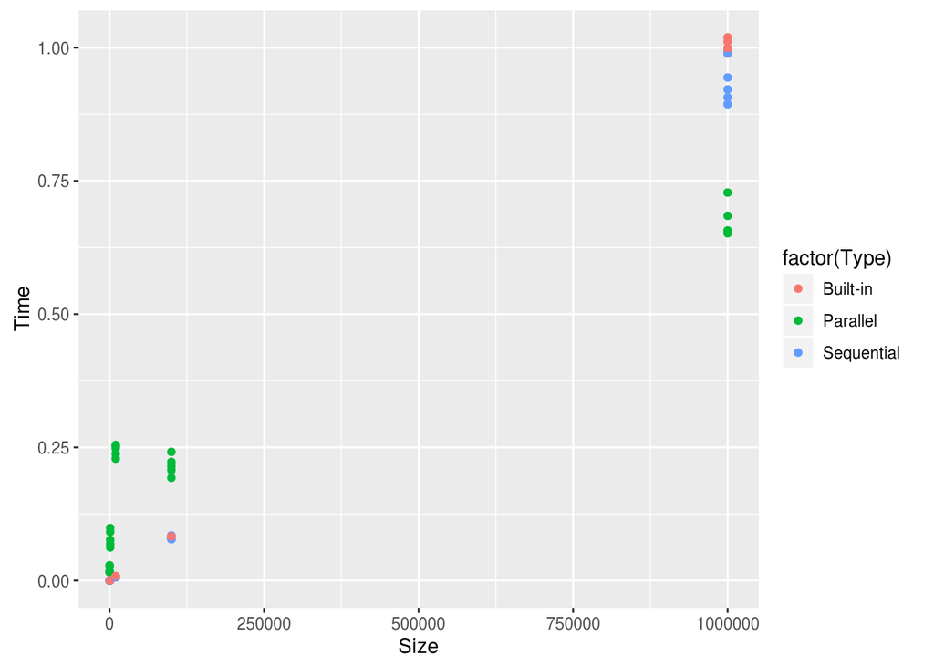

```r
ggplot(data, aes(x=Size, y=Time, color = factor(Type))) + geom_point()
```

We try to analyse this data by te linear regression. But as we can see, this data does not provide much information, so we don’t get the result as expected.

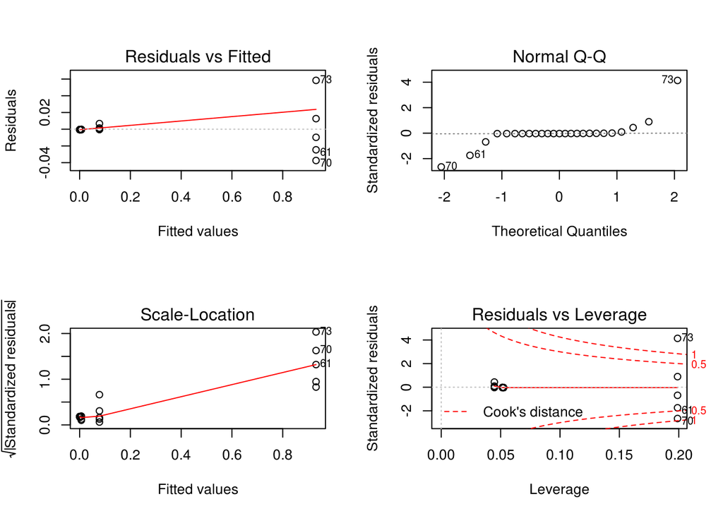

```r
#test = aggregate(dataSeq$Time, by=list(Category=dataSeq$Size), FUN=mean)
dataSeq = data[data$Type==" Sequential",]
reg <- lm(data = dataSeq, dataSeq$Time~I(dataSeq$Size*log(dataSeq$Size)))
par(mfrow = c(2,2))
plot(reg)
```

```r
summary(reg)
```

```
##
## Call:
## lm(formula = dataSeq$Time ~ I(dataSeq$Size * log(dataSeq$Size)),
##     data = dataSeq)
##
## Residuals:
##       Min        1Q    Median        3Q       Max
## -0.037429 -0.000520 -0.000502 -0.000250  0.058450
##
## Coefficients:
##                                      Estimate Std. Error t value Pr(>|t|)
## (Intercept)                         5.207e-04  3.612e-03   0.144    0.887
## I(dataSeq$Size * log(dataSeq$Size)) 6.737e-08  5.826e-10 115.642   <2e-16
##
## (Intercept)
## I(dataSeq$Size * log(dataSeq$Size)) ***
## ---
## Signif. codes:  0 '***' 0.001 '**' 0.01 '*' 0.05 '.' 0.1 ' ' 1
##
## Residual standard error: 0.01578 on 23 degrees of freedom
## Multiple R-squared:  0.9983, Adjusted R-squared:  0.9982
## F-statistic: 1.337e+04 on 1 and 23 DF,  p-value: < 2.2e-16
```

We need more data to make the conclusion. So we do some new experiments, and here is the result.

# 2 : Take new data

We run the code provided in the archive to get more data, and add new size of sorted lists.

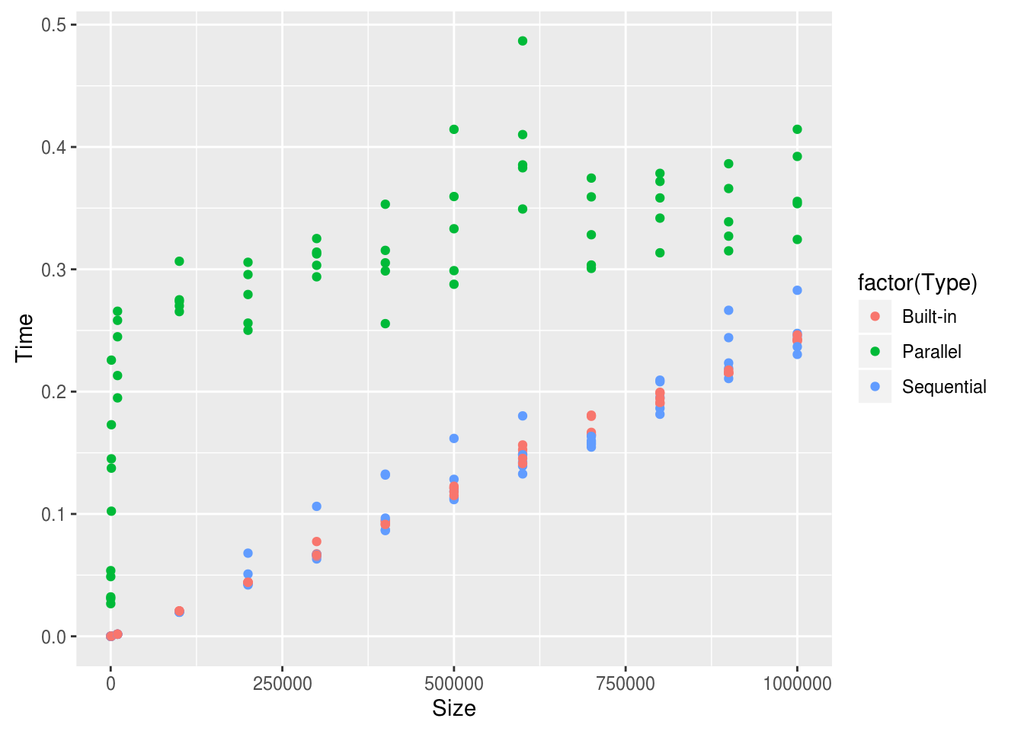

```r
data_1 = read.csv("archive_quicksort/measurements_computer1.csv")

ggplot(data_1, aes(x=Size, y=Time, color = factor(Type))) + geom_point()
```

## 2.1 : Data Analysis

On this experiment, we see that the parallel algorithm have the bigger variance than the others. We can observe that comparing to the first experiment, for the large n, parallel algorithm runs much faster than the two others. But in this experiment, it runs very slow comparing to the two others.

```r
dataSeq_1 = data_1[data$Type==" Sequential",]
reg <- lm(data = dataSeq_1, dataSeq_1$Time~I(dataSeq_1$Size*log(dataSeq_1$Size)))
summary(reg)
```

```
##
## Call:
## lm(formula = dataSeq_1$Time ~ I(dataSeq_1$Size * log(dataSeq_1$Size)),
##     data = dataSeq_1)
##
## Residuals:
##       Min        1Q    Median        3Q       Max
## -0.021697 -0.007498 -0.003209 -0.002402  0.041039
##
## Coefficients:
##                                          Estimate Std. Error t value
## (Intercept)                             2.520e-03  2.876e-03   0.876
## I(dataSeq_1$Size * log(dataSeq_1$Size)) 1.807e-08  3.905e-10  46.269
##                                         Pr(>|t|)
## (Intercept)                                0.384
## I(dataSeq_1$Size * log(dataSeq_1$Size))   <2e-16 ***
## ---
## Signif. codes:  0 '***' 0.001 '**' 0.01 '*' 0.05 '.' 0.1 ' ' 1
##
## Residual standard error: 0.01482 on 63 degrees of freedom
## Multiple R-squared:  0.9714, Adjusted R-squared:  0.971
## F-statistic:  2141 on 1 and 63 DF,  p-value: < 2.2e-16
```

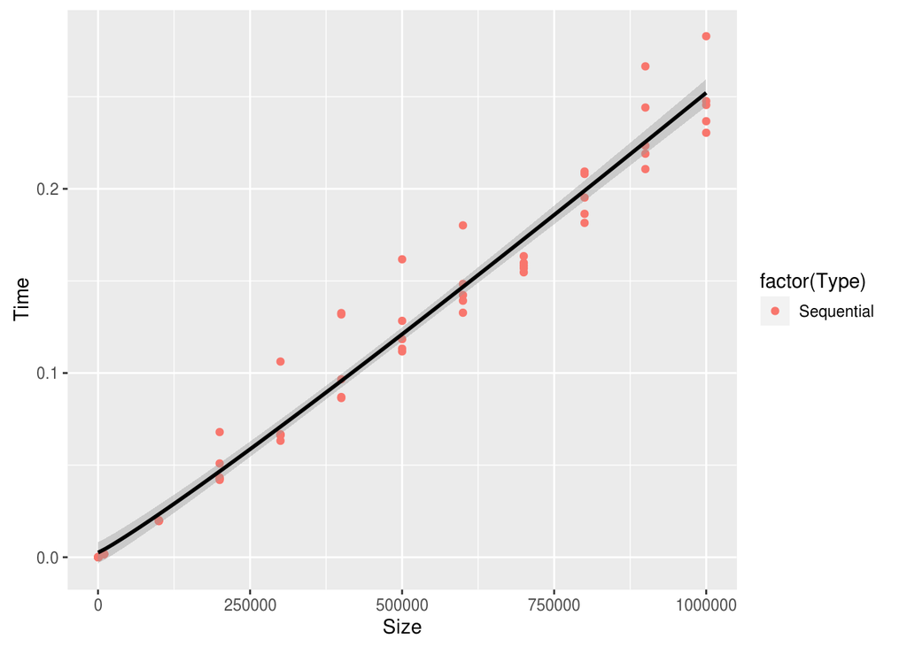

```r
graph = ggplot(dataSeq_1, aes(x=Size, y=Time, color = factor(Type))) + geom_point()

graph + geom_smooth(method = "lm", formula = y ~ I(x*log(x)), color = "black")
```

For the sequential algorithm, we obtain that the best regression line is y = O(xlog(x)) (so far, we don’t know if there is another one which is better).

```r
dataBIn_1 = data_1[data$Type==" Built-in",]
reg <- lm(data = dataBIn_1, dataBIn_1$Time~I(dataBIn_1$Size*log(dataBIn_1$Size)))
summary(reg)
```

```
##
## Call:
## lm(formula = dataBIn_1$Time ~ I(dataBIn_1$Size * log(dataBIn_1$Size)),
##     data = dataBIn_1)
##
## Residuals:
##        Min         1Q     Median         3Q        Max
## -0.0053582 -0.0016143 -0.0011425  0.0001762  0.0135987
##
## Coefficients:
##                                          Estimate Std. Error t value
## (Intercept)                             1.186e-03  8.036e-04   1.475
## I(dataBIn_1$Size * log(dataBIn_1$Size)) 1.774e-08  1.091e-10 162.596
##                                         Pr(>|t|)
## (Intercept)                                0.145
## I(dataBIn_1$Size * log(dataBIn_1$Size))   <2e-16 ***
## ---
## Signif. codes:  0 '***' 0.001 '**' 0.01 '*' 0.05 '.' 0.1 ' ' 1
##
## Residual standard error: 0.004141 on 63 degrees of freedom
## Multiple R-squared:  0.9976, Adjusted R-squared:  0.9976
## F-statistic: 2.644e+04 on 1 and 63 DF,  p-value: < 2.2e-16
```

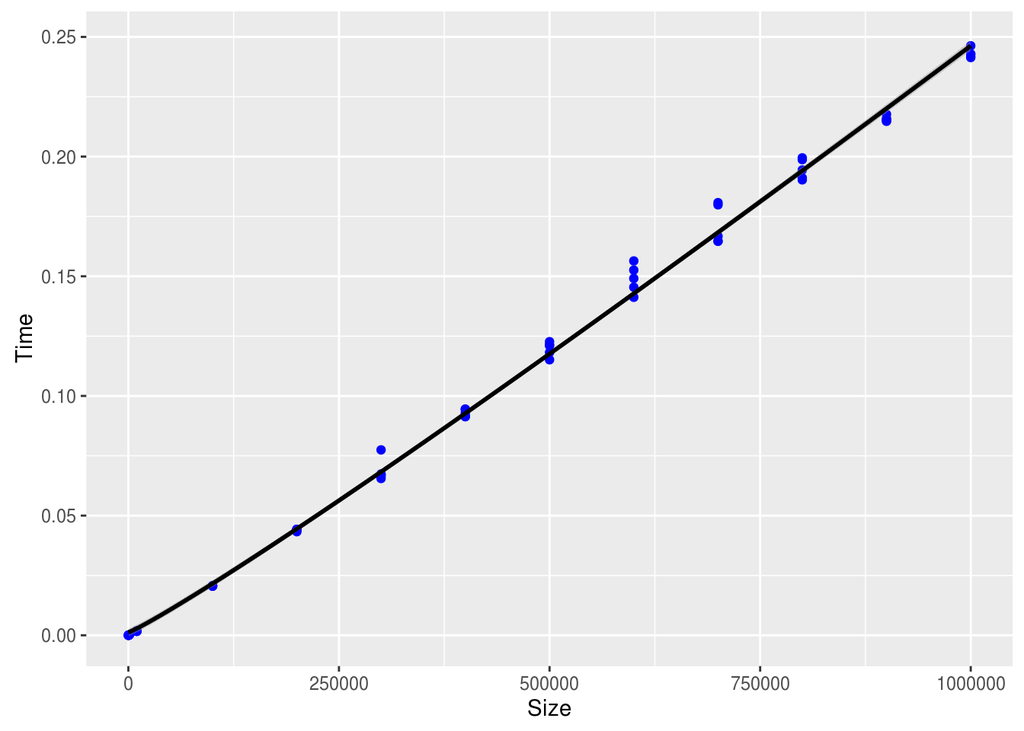

```r
graph = ggplot(dataBIn_1, aes(x=Size, y=Time, color = factor(Type))) + geom_point(color = "blue")

graph + geom_smooth(method = "lm", formula = y ~ I(x*log(x)), color ="black")
```

The built-in method give almost the same results that the sequential one, can we assume that they can be implemented in the same way?

```r
dataPar_1 = data_1[data$Type==" Parallel",]
reg <- lm(data = dataPar_1, dataPar_1$Time~I(dataPar_1$Size*log(dataPar_1$Size)))
summary(reg)
```

```
##
## Call:
## lm(formula = dataPar_1$Time ~ I(dataPar_1$Size * log(dataPar_1$Size)),
##     data = dataPar_1)
##
## Residuals:
##      Min       1Q   Median       3Q      Max
## -0.17599 -0.04111  0.01193  0.05290  0.16377
##
## Coefficients:
##                                          Estimate Std. Error t value
## (Intercept)                             2.026e-01  1.354e-02  14.967
## I(dataPar_1$Size * log(dataPar_1$Size)) 1.507e-08  1.838e-09   8.197
##                                         Pr(>|t|)
## (Intercept)                              < 2e-16 ***
## I(dataPar_1$Size * log(dataPar_1$Size)) 1.62e-11 ***
## ---
## Signif. codes:  0 '***' 0.001 '**' 0.01 '*' 0.05 '.' 0.1 ' ' 1
##
## Residual standard error: 0.06978 on 63 degrees of freedom
## Multiple R-squared:  0.5161, Adjusted R-squared:  0.5084
## F-statistic: 67.19 on 1 and 63 DF,  p-value: 1.615e-11
```

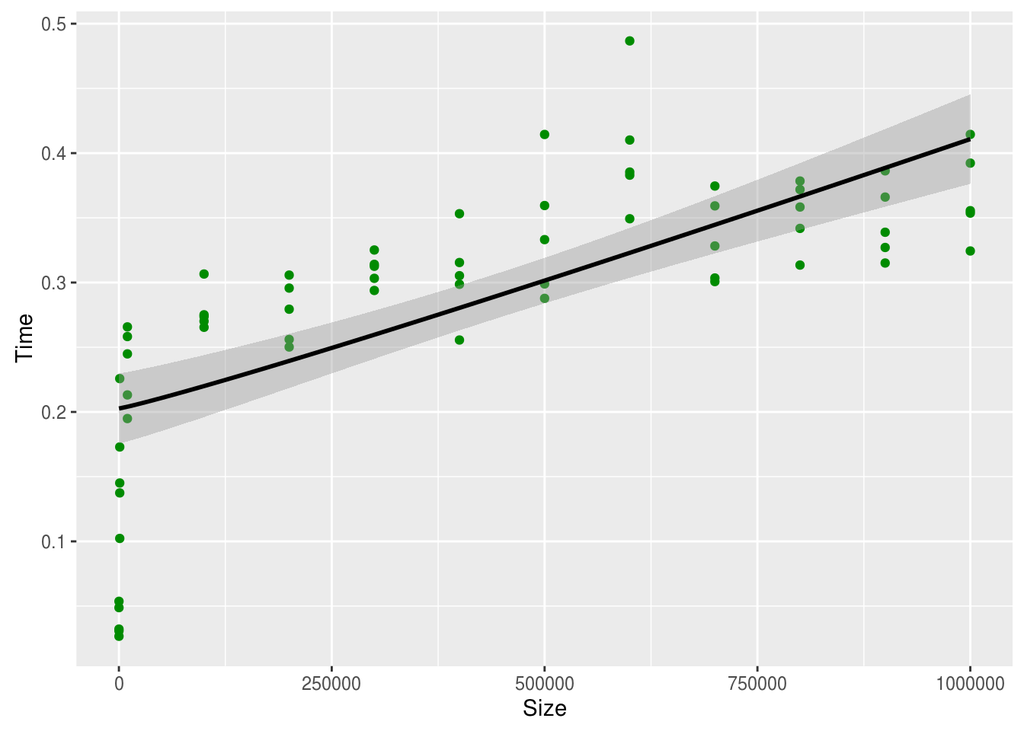

```r
graph = ggplot(dataPar_1, aes(x=Size, y=Time, color = factor(Type))) + geom_point(color="green4")

graph + geom_smooth(method = "lm", formula = y ~ I(x*log(x)), color="black")
```

This regression line is y = O(x*log(x)), but it doesn’t match with the data. So, we try to approximate with y = O(log(x)), and the result is the following.

```r
reg <- lm(data = dataPar_1, dataPar_1$Time~I(log(dataPar_1$Size)))
summary(reg)
```

```
##
## Call:
## lm(formula = dataPar_1$Time ~ I(log(dataPar_1$Size)), data = dataPar_1)
##
## Residuals:
##       Min        1Q    Median        3Q       Max
## -0.074338 -0.027545 -0.006495  0.022304  0.143584
##
## Coefficients:
##                         Estimate Std. Error t value Pr(>|t|)
## (Intercept)            -0.090250   0.020465   -4.41 4.11e-05 ***
## I(log(dataPar_1$Size))  0.032573   0.001713   19.01  < 2e-16 ***
## ---
## Signif. codes:  0 '***' 0.001 '**' 0.01 '*' 0.05 '.' 0.1 ' ' 1
##
## Residual standard error: 0.03865 on 63 degrees of freedom
## Multiple R-squared:  0.8516, Adjusted R-squared:  0.8492
## F-statistic: 361.4 on 1 and 63 DF,  p-value: < 2.2e-16
```

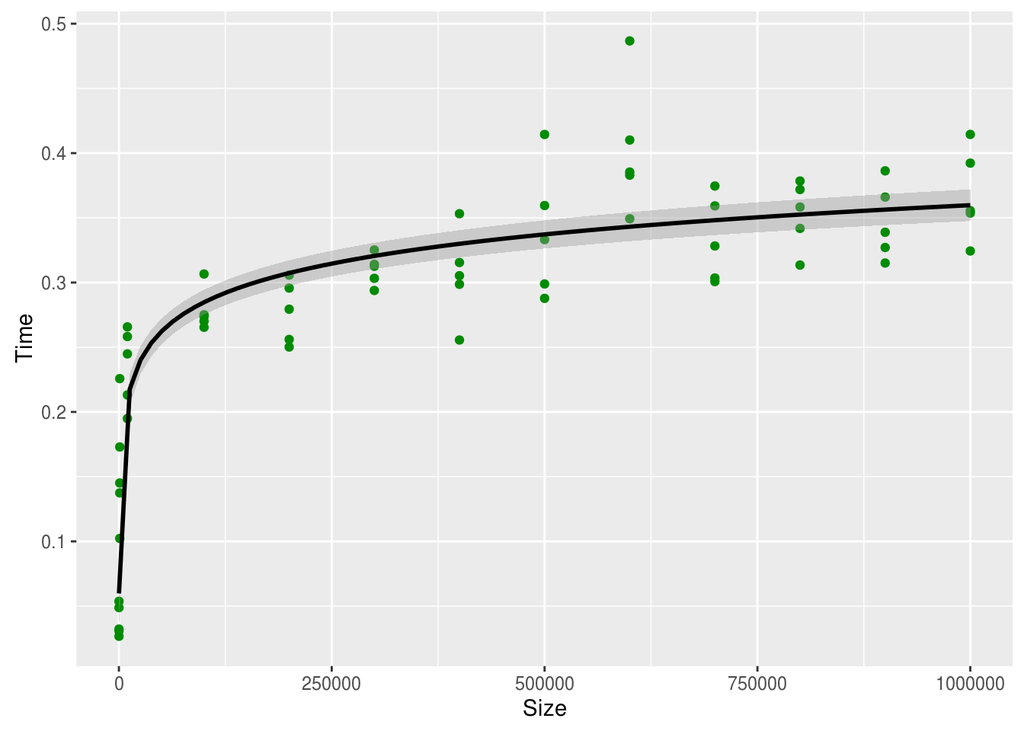

```r
graph = ggplot(dataPar_1, aes(x=Size, y=Time, color = factor(Type))) + geom_point(color="green4")

graph + geom_smooth(method = "lm", formula = y ~ log(x), color="black")
```

This one is better than the previous one.

## 2.2 : Need more data ?

We see that the parallel algorithm have a totally different result between the two dataset, we decide to do other experiments with more computers.

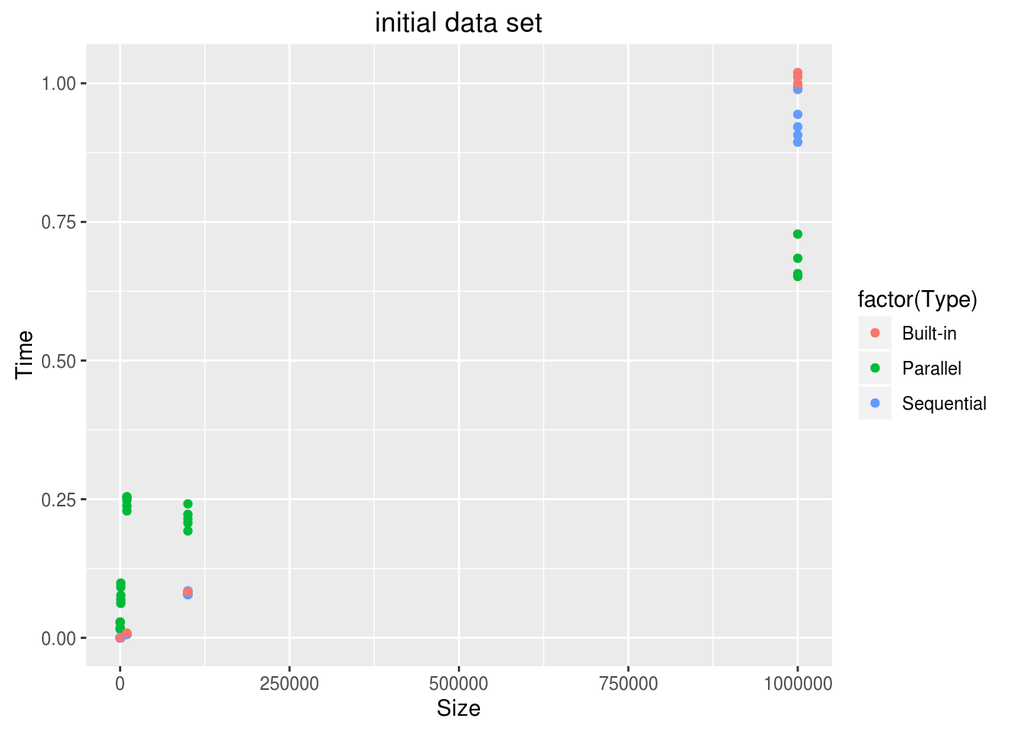

```r
my_read_data = function(filename) {
  df = read.csv(filename);
  df$origin = filename
  df
}
data = my_read_data("archive_quicksort/_measurements.csv")
data_1 = my_read_data("archive_quicksort/measurements_computer1.csv")
data_2 = my_read_data("archive_quicksort/measurements_computer2.csv")
data_3 = my_read_data("archive_quicksort/measurements_computer3.csv")


data_tot=rbind(data, data_1, data_2,data_3)

data_tot$origin = gsub(pattern = ".*_",replacement = "",data_tot$origin)
data_tot$origin = gsub(pattern = ".csv",replacement = "",data_tot$origin)
data_tot$origin = gsub(pattern = "measurements",replacement = "origin",data_tot$origin)


#ggplot(data_tot, aes(x=Size, y=Time, color = factor(Type))) + ggtitle("initial data set") + geom_point() + facet_wrap(~origin)
ggplot(data, aes(x=Size, y=Time, color = factor(Type))) + ggtitle("initial data set") + geom_point()
```

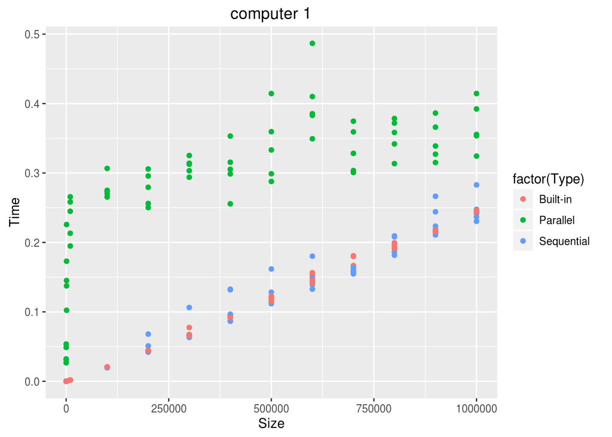

```r
ggplot(data_1, aes(x=Size, y=Time, color = factor(Type))) + ggtitle("computer 1") + geom_point()
```

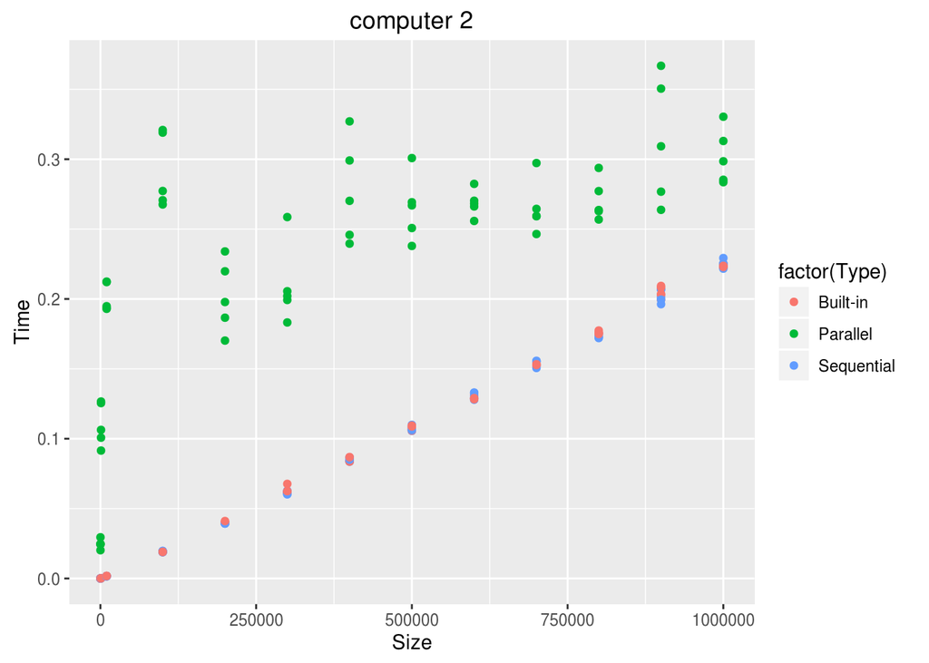

```r
ggplot(data_2, aes(x=Size, y=Time, color = factor(Type))) + ggtitle("computer 2") + geom_point()
```

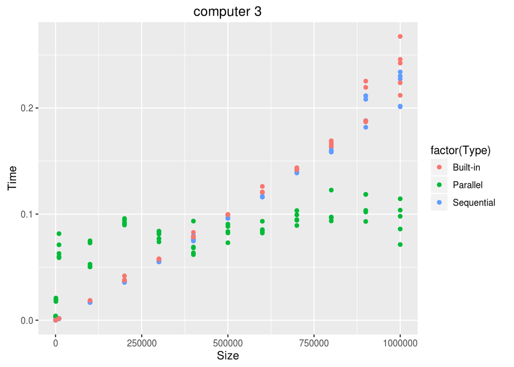

```r
ggplot(data_3, aes(x=Size, y=Time, color = factor(Type))) + ggtitle("computer 3") + geom_point()
```

In fact, we cannot say which algorithm is the best one, because the result depends on the value of n. In general, we think that the parallel algorithm gives the best result when n is sufficiently large.

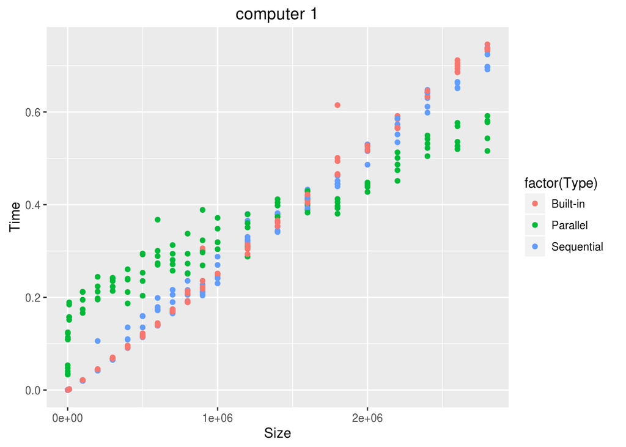

```r
data_1_2 = my_read_data("archive_quicksort/measurements_computer1_2.csv")
ggplot(data_1_2, aes(x=Size, y=Time, color = factor(Type))) + ggtitle("computer 1") + geom_point()
```

We take more data on computer1 to check if the parallel algorithm give better result on large n.

```r
#rmarkdown::render("smpe.rmd")
```